# 2_MLPS_R_visualization

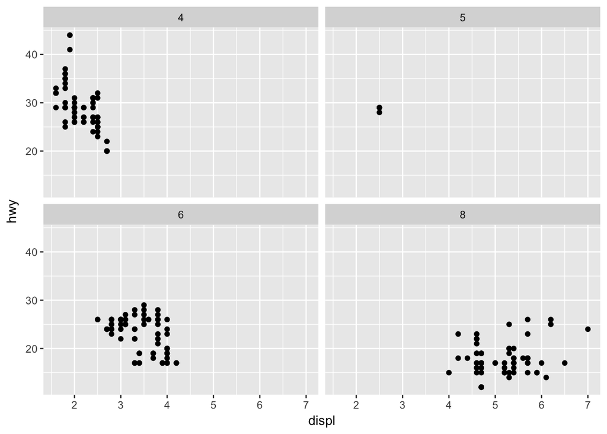

```r
ggplot(mpg, aes(x = displ, y = hwy)) +
  geom_point() + facet_wrap(~cyl)
```

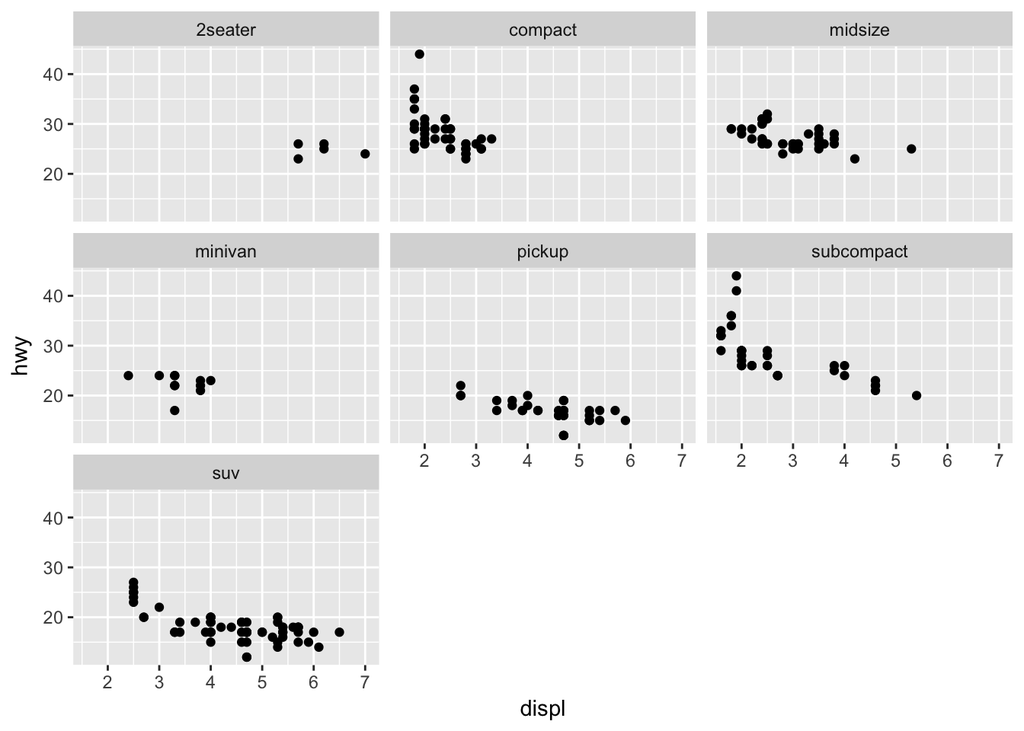

```r
ggplot(mpg, aes(x = displ, y = hwy)) +
  geom_point() + facet_wrap(~class)
```

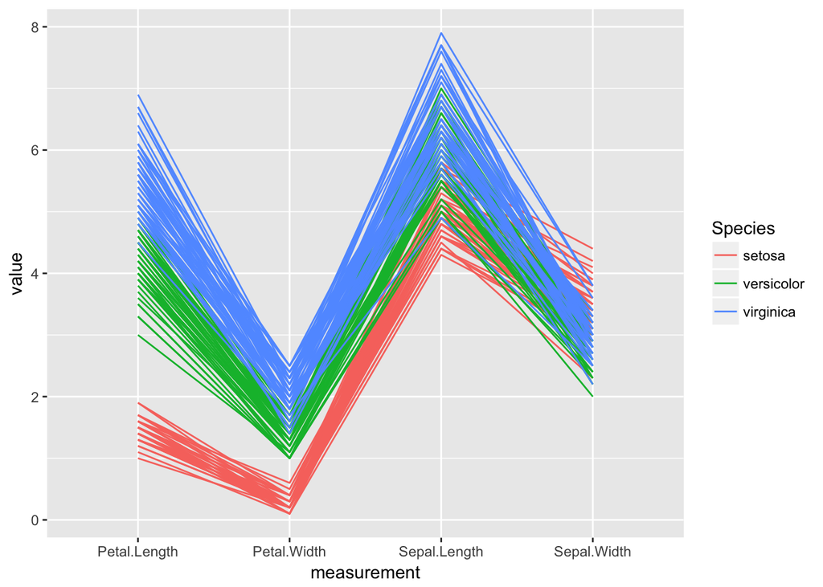

```r
# parallel coordinates
#   for some
long_iris_df <- iris %>% mutate(obs_id = row_number()) %>%
  gather(key = measurement, value = value, -obs_id, -Species)
ggplot(long_iris_df,
       aes(x = measurement, y = value,
           group = obs_id, color = Species)) +
  geom_line()
```

```r
# radar plots
#   if you're interested, check out this ggplot2 extension
# http://www.ggplot2-exts.org/ggradar.html
```

Notes from the above examples:

- in the parallel coordinates example, note that we could not have plotted this without making the iris data a long dataset, where each measurement of an observation gets one row. `ggplot` enforces this structure because it makes it clear what we’re studying. In this case, we’re interested in comparing the different measurements against each other, so measurement type should be a variable (hence, row), rather than a particular description of a measurement (i.e. column). This follows the tidy data philosophy (see R4DS for more).
- when doing line plots, it can be important to specify how we’re connecting/grouping our data into a line. Use the `group` aesthetic to guide this and think through this.